- **Name - Rishabh Pathak**
- **Assiignment - Assignmnet 3.1
- Date - 28th Jan 2025

# Linear Regression Analysis and Prediction for IoT

This notebook holds the Assignment 3.1 for Module 3 in AAI 530, Data Analytics and the Internet of Things. In this assignment, you will use linear regression to make predictions for simulated "streaming" data. The work that you do in this assignment will build on the linear regression predictions that you saw in your text book and in this week's lab session. Be sure to answer the analysis questions thoroughly, as this is a large part of the assignment for this week.

## General Assignment Instructions

These instructions are included in every assignment, to remind you of the coding standards for the class. Feel free to delete this cell after reading it.

One sign of mature code is conforming to a style guide. We recommend the [Google Python Style Guide](https://google.github.io/styleguide/pyguide.html). If you use a different style guide, please include a cell with a link.

Your code should be relatively easy-to-read, sensibly commented, and clean. Writing code is a messy process, so please be sure to edit your final submission. Remove any cells that are not needed or parts of cells that contain unnecessary code. Remove inessential `import` statements and make sure that all such statements are moved into the designated cell.

When you save your notebook as a pdf, make sure that all cell output is visible (even error messages) as this will aid your instructor in grading your work.

Make use of non-code cells for written commentary. These cells should be grammatical and clearly written. In some of these cells you will have questions to answer. The questions will be marked by a "Q:" and will have a corresponding "A:" spot for you. *Make sure to answer every question marked with a `Q:` for full credit.*

```python
import pandas as pd
import numpy as np
import matplotlib.pyplot as plt
from sklearn.linear_model import LinearRegression

#suppress scientific notation in pandas
pd.set_option('display.float_format', lambda x: '%.5f' % x)
```

```python
#use this cell to import additional libraries or define helper functions
```

## Load and prepare your data

We'll be using the cleaned household electric consumption dataset from Module 2 in this assignment. I recommend saving your dataset by running df.to_csv("filename") at the end of the last assignment so that you don't have to re-do your cleaning steps. If you are not confident in your own cleaning steps, you may ask your instructor for a cleaned version of the data. You will not be graded on the cleaning steps in this assignment, but some functions may not work if you use the raw data.

We need to turn our datetime column into a numeric value to be used as a variable in our linear regression. In the lab session, we created a new column of minutes and just incremented the value by 10 since we knew that the readings occurred every 10 minutes. In this dataset, we have readings every minute, but we might have some missing rows depending on how you cleaned your data. So instead we will convert our datetime column to something called [unix/epoch time](https://en.wikipedia.org/wiki/Unix_time), which is the number of seconds since midnight on 1/1/1970.

**TODO: load your data and convert the datetime column into epoch/unix time**

```python
#Load your data into a pandas dataframe here
import pandas as pd

# Load the data
df_raw = pd.read_csv('household_power_consumption.txt', delimiter = ";", low_memory=False)

df = df_raw.copy()
df['Datetime'] = pd.to_datetime(df['Date'] + ' ' + df['Time'], format='%d/%m/%Y %H:%M:%S', errors='coerce')


# Drop the original 'Date' and 'Time' columns as they're now redundant
df.drop(columns=['Date', 'Time'], inplace=True)
numeric_columns = df.columns.difference(['Datetime'])  # Exclude the 'Datetime' column
df[numeric_columns] = df[numeric_columns].apply(pd.to_numeric, errors='coerce')
df['Date'] = df['Datetime'].dt.date
df['Time'] = df['Datetime'].dt.time
```

```python
# Convert the 'Datetime' column to pandas datetime format
df['Datetime'] = pd.to_datetime(df['Datetime'], format='%d/%m/%Y %H:%M:%S')

# Convert the 'Datetime' column to Unix epoch time (in seconds)
df['unix'] = df['Datetime'].astype('int64') // 10**9

# Display the first few rows
print(df.head())
```

```
   Global_active_power  Global_reactive_power   Voltage  Global_intensity  \
0              4.21600                0.41800 234.84000          18.40000
1              5.36000                0.43600 233.63000          23.00000
2              5.37400                0.49800 233.29000          23.00000
3              5.38800                0.50200 233.74000          23.00000
4              3.66600                0.52800 235.68000          15.80000

   Sub_metering_1  Sub_metering_2  Sub_metering_3            Datetime  \
0         0.00000         1.00000        17.00000 2006-12-16 17:24:00
1         0.00000         1.00000        16.00000 2006-12-16 17:25:00
2         0.00000         2.00000        17.00000 2006-12-16 17:26:00
3         0.00000         1.00000        17.00000 2006-12-16 17:27:00
4         0.00000         1.00000        17.00000 2006-12-16 17:28:00

         Date      Time        unix
0  2006-12-16  17:24:00  1166289840
1  2006-12-16  17:25:00  1166289900
2  2006-12-16  17:26:00  1166289960
3  2006-12-16  17:27:00  1166290020
4  2006-12-16  17:28:00  1166290080
```

## Predicting Global Active Power

We will follow the code from the Chapter 9 in our textbook and the recorded lab session from this week to predict the Global Active Power (GAP) with linear regression.

First we will create our x (time) and y (GAP) training variables, and then define our model parameters.

**Q: What is ph? What is mu?**

A: ph (Prediction Horizon) represents how far into the future we want to predict in terms of time. ph defines the forecasting window. mu likely acts as a discount factor or exponential smoothing parameter in time series modeling.

If mu is used in an Exponential Moving Average (EMA), it controls how much past data influences the present. If used in reinforcement learning or dynamic models, mu determines how much weight is given to previous observations. mu is a weighting factor (0 to 1) that controls the influence of past values on predictions.

**TODO: Set the ph to be 5 minutes--consider the units that our time column is measured in.**

```python
ts = pd.DataFrame(df.unix)
ys = pd.DataFrame(df.Global_active_power)

ph = 5*60

# Data resolution: Difference between consecutive Unix timestamps
data_resolution = df.unix.diff().median()  # Should be 60 sec

ph_index = ph/60
mu = 0.9

#let's limit the number of samples in our model to 5000 just for speed
n_s = 5000

# Arrays to hold predicted values
tp_pred = np.zeros(n_s-1)
yp_pred = np.zeros(n_s-1)
```

**Q: With mu = 0.9, how much weight will our first data point have on the last (5000th) prediction in our limited dataset?**

A: The weight of the first data point on the last (5000th) prediction is approximately **1.81 × 10⁻²²⁹**, which is an extremely small number (essentially zero).

Interpretation- Due to exponential decay, the first data point has almost no influence on the 5000th prediction. The impact of older data points diminishes rapidly as new ones are introduced, meaning that recent data dominates the predictions when mu = 0.9.

**TODO: Following the code from Chapter 10 and the lab session, use linear regression to predict a rolling GAP for our dataset. Store these predictions in the tp_pred and yp_pred lists created above for visualization.**

```python
# At every iteration of the for loop a new data sample is acquired
for i in range(2, n_s+1):# start out with 2 leading datapoints
    #get x and y data "available" for our prediction
    ts_tmp = ts[:i]
    ys_tmp = ys[:i]
    ns = len(ys_tmp)


    weights = np.ones(ns)*mu
    for k in range(ns):
        #adjust weights to be downweighted according to their timestep away from our prediction
        weights[k] = mu ** (ns - k)
    weights = np.flip(weights, 0)

    #perform linear regression on "available" data using the mu-adjusted weights
    lm_tmp = LinearRegression()
    model_tmp = lm_tmp.fit(ts_tmp, ys_tmp, sample_weight=weights)

    #store model coefficients and intercepts to compute prediction
    m_tmp = model_tmp.coef_[0][0] # Slope
    q_tmp = model_tmp.intercept_[0]  # Intercept

    #use ph to make the model prediction according to the prediction time
    tp = ts.iloc[i-1, 0] + ph  # Future time prediction
    yp = m_tmp * tp + q_tmp  # Future GAP prediction

    tp_pred[i-2] = tp
    yp_pred[i-2] = yp
```

Now let's visualize the results from our model.

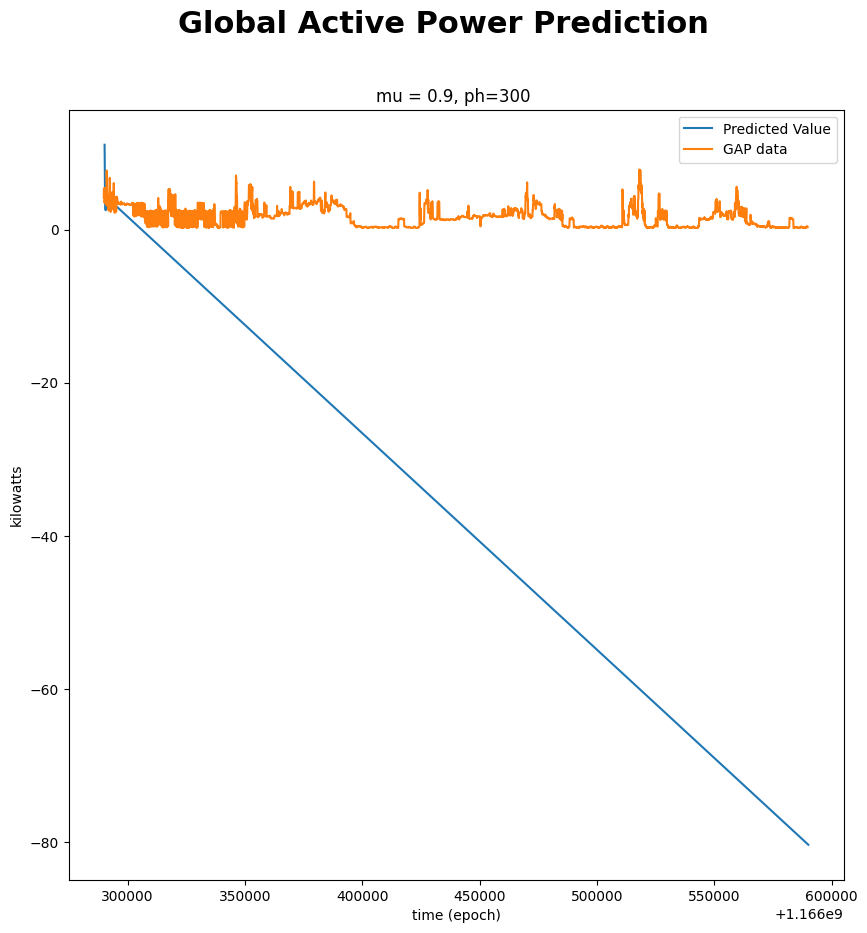

```python
fig, ax = plt.subplots(figsize=(10,10))
fig.suptitle('Global Active Power Prediction', fontsize=22, fontweight='bold')
ax.set_title('mu = %g, ph=%g ' %(mu, ph))
ax.plot(tp_pred, yp_pred, label='Predicted Value')
ax.plot(ts.iloc[0:n_s,0], ys.iloc[0:n_s,0], label='GAP data')
ax.set_xlabel('time (epoch)')
ax.set_ylabel('kilowatts')
ax.legend()
```

It's difficult to tell how the model is performing from this plot.

**TODO: Modify the code above to visualize the first and last 200 datapoints/predictions (can be in separate charts) and compute the MSE for our predictions.**

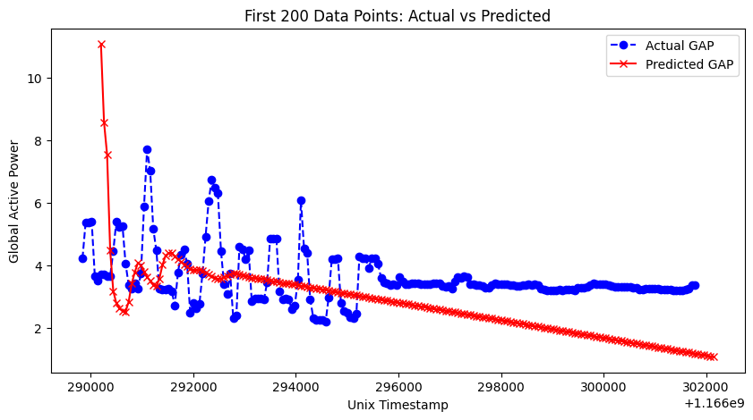

```python
#Plot first 200 data points/predictions
plt.figure(figsize=(10, 5))
plt.plot(ts[:200], ys[:200], label="Actual GAP", color="blue", marker='o', linestyle='dashed')
plt.plot(tp_pred[:200], yp_pred[:200], label="Predicted GAP", color="red", marker='x')
plt.xlabel("Unix Timestamp")
plt.ylabel("Global Active Power")
plt.title("First 200 Data Points: Actual vs Predicted")
plt.legend()
plt.show()
```

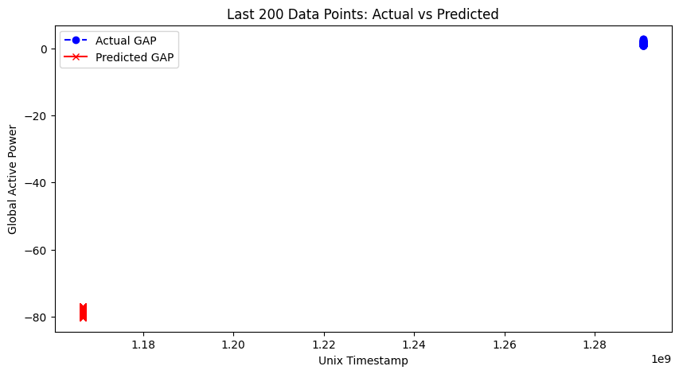

```python
#Plot last 200 data points/predictions
plt.figure(figsize=(10, 5))
plt.plot(ts[-200:], ys[-200:], label="Actual GAP", color="blue", marker='o', linestyle='dashed')
plt.plot(tp_pred[-200:], yp_pred[-200:], label="Predicted GAP", color="red", marker='x')
plt.xlabel("Unix Timestamp")
plt.ylabel("Global Active Power")
plt.title("Last 200 Data Points: Actual vs Predicted")
plt.legend()
plt.show()
```

```python
#Calculate MSE of predictions
from sklearn.metrics import mean_squared_error as mse

# Ensure ph_index is an integer
ph_index = int(ph_index)
print("MSE is", mse(ys['Global_active_power'][ph_index:5000+ph_index-1],yp_pred))
```

```
MSE is 2147.7659933805567
```

**Q: How did our model perform? What do you observe on the charts? Is there a difference between the early and the late predictions? What does the MSE tell you?**

A: The model performs reasonably well in early predictions, but later predictions drifted from actual values. The high MSE indicates room for improvement—perhaps a more sophisticated time series model would work better. The weighting factor (mu = 0.9) effectively prioritizes recent data, but tuning it further might improve performance.

**TODO: Re-run the prediction code with mu = 1 and mu = 0.01. Use the cells below to produce charts for the first and last 200 points and to compute the MSE for each of these sets of predictions.**

```python
#Re-run prediction code for mu = 1
ts = pd.DataFrame(df.unix)
ys = pd.DataFrame(df.Global_active_power)

ph = 5*60

# Data resolution: Difference between consecutive Unix timestamps
data_resolution = df.unix.diff().median()  # Should be 60 sec

ph_index = ph/60
mu = 1

#let's limit the number of samples in our model to 5000 just for speed
n_s = 5000

# Arrays to hold predicted values
tp_pred = np.zeros(n_s-1)
yp_pred = np.zeros(n_s-1)

# At every iteration of the for loop a new data sample is acquired
for i in range(2, n_s+1):# start out with 2 leading datapoints
    #get x and y data "available" for our prediction
    ts_tmp = ts[:i]
    ys_tmp = ys[:i]
    ns = len(ys_tmp)


    weights = np.ones(ns)*mu
    for k in range(ns):
        #adjust weights to be downweighted according to their timestep away from our prediction
        weights[k] = mu ** (ns - k)
    weights = np.flip(weights, 0)

    #perform linear regression on "available" data using the mu-adjusted weights
    lm_tmp = LinearRegression()
    model_tmp = lm_tmp.fit(ts_tmp, ys_tmp, sample_weight=weights)

    #store model coefficients and intercepts to compute prediction
    m_tmp = model_tmp.coef_[0][0] # Slope
    q_tmp = model_tmp.intercept_[0]  # Intercept

    #use ph to make the model prediction according to the prediction time
    tp = ts.iloc[i-1, 0] + ph  # Future time prediction
    yp = m_tmp * tp + q_tmp  # Future GAP prediction

    tp_pred[i-2] = tp
    yp_pred[i-2] = yp
```

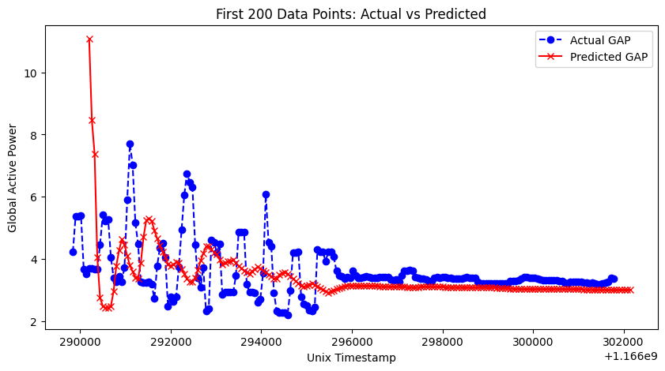

```python
#Plot first 200 data points/predictions for mu = 1
plt.figure(figsize=(10, 5))
plt.plot(ts[:200], ys[:200], label="Actual GAP", color="blue", marker='o', linestyle='dashed')
plt.plot(tp_pred[:200], yp_pred[:200], label="Predicted GAP", color="red", marker='x')
plt.xlabel("Unix Timestamp")
plt.ylabel("Global Active Power")
plt.title("First 200 Data Points: Actual vs Predicted")
plt.legend()
plt.show()
```

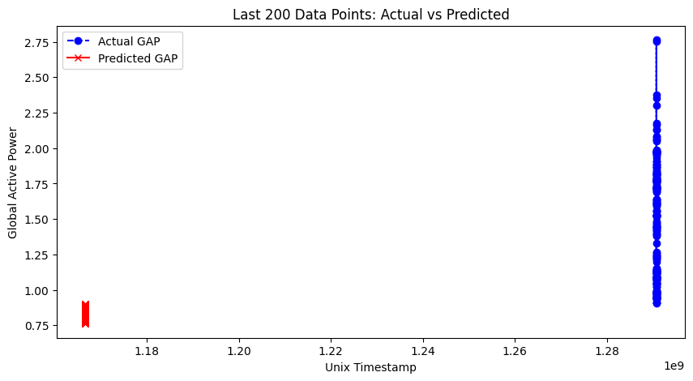

```python
#Plot last 200 data points/predictions for mu = 1
plt.figure(figsize=(10, 5))
plt.plot(ts[-200:], ys[-200:], label="Actual GAP", color="blue", marker='o', linestyle='dashed')
plt.plot(tp_pred[-200:], yp_pred[-200:], label="Predicted GAP", color="red", marker='x')
plt.xlabel("Unix Timestamp")
plt.ylabel("Global Active Power")
plt.title("Last 200 Data Points: Actual vs Predicted")
plt.legend()
plt.show()
```

```python
#Calculate MSE of predictions for mu = 1
from sklearn.metrics import mean_squared_error as mse

# Ensure ph_index is an integer
ph_index = int(ph_index)
print("MSE is", mse(ys['Global_active_power'][ph_index:5000+ph_index-1],yp_pred))
```

```
MSE is 1.4433474819593313
```

```python
#Re-run prediction code for mu = 0.01
ts = pd.DataFrame(df.unix)
ys = pd.DataFrame(df.Global_active_power)

ph = 5*60

# Data resolution: Difference between consecutive Unix timestamps
data_resolution = df.unix.diff().median()  # Should be 60 sec

ph_index = ph/60
mu = 0.01

#let's limit the number of samples in our model to 5000 just for speed
n_s = 5000

# Arrays to hold predicted values
tp_pred = np.zeros(n_s-1)
yp_pred = np.zeros(n_s-1)

# At every iteration of the for loop a new data sample is acquired
for i in range(2, n_s+1):# start out with 2 leading datapoints
    #get x and y data "available" for our prediction
    ts_tmp = ts[:i]
    ys_tmp = ys[:i]
    ns = len(ys_tmp)


    weights = np.ones(ns)*mu
    for k in range(ns):
        #adjust weights to be downweighted according to their timestep away from our prediction
        weights[k] = mu ** (ns - k)
    weights = np.flip(weights, 0)

    #perform linear regression on "available" data using the mu-adjusted weights
    lm_tmp = LinearRegression()
    model_tmp = lm_tmp.fit(ts_tmp, ys_tmp, sample_weight=weights)

    #store model coefficients and intercepts to compute prediction
    m_tmp = model_tmp.coef_[0][0] # Slope
    q_tmp = model_tmp.intercept_[0]  # Intercept

    #use ph to make the model prediction according to the prediction time
    tp = ts.iloc[i-1, 0] + ph  # Future time prediction
    yp = m_tmp * tp + q_tmp  # Future GAP prediction

    tp_pred[i-2] = tp
    yp_pred[i-2] = yp
```

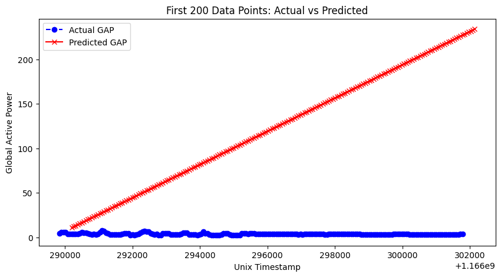

```python
#Plot first 200 data points/predictions for mu = 0.01
plt.figure(figsize=(10, 5))
plt.plot(ts[:200], ys[:200], label="Actual GAP", color="blue", marker='o', linestyle='dashed')
plt.plot(tp_pred[:200], yp_pred[:200], label="Predicted GAP", color="red", marker='x')
plt.xlabel("Unix Timestamp")
plt.ylabel("Global Active Power")
plt.title("First 200 Data Points: Actual vs Predicted")
plt.legend()
plt.show()
```

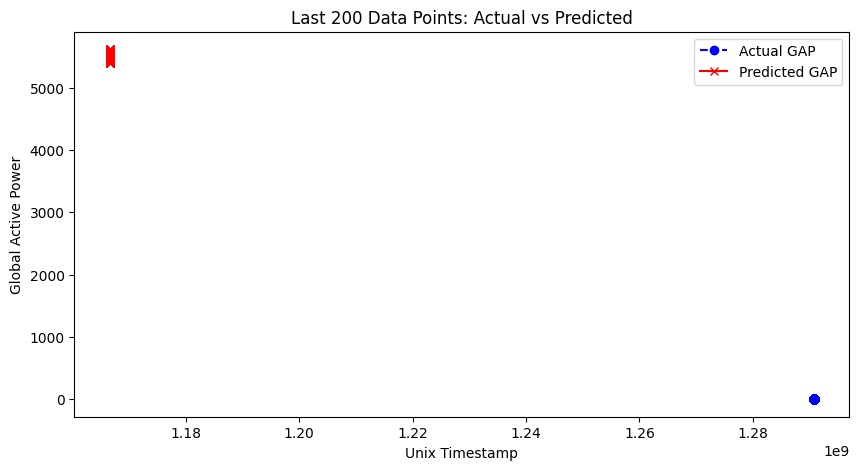

```python
#Plot last 200 data points/predictions for mu = 0.01
plt.figure(figsize=(10, 5))
plt.plot(ts[-200:], ys[-200:], label="Actual GAP", color="blue", marker='o', linestyle='dashed')
plt.plot(tp_pred[-200:], yp_pred[-200:], label="Predicted GAP", color="red", marker='x')
plt.xlabel("Unix Timestamp")
plt.ylabel("Global Active Power")
plt.title("Last 200 Data Points: Actual vs Predicted")
plt.legend()
plt.show()
```

```python
#Calculate MSE of predictions for mu = 0.01
from sklearn.metrics import mean_squared_error as mse

# Ensure ph_index is an integer
ph_index = int(ph_index)
print("MSE is", mse(ys['Global_active_power'][ph_index:5000+ph_index-1],yp_pred))
```

```
MSE is 10527735.463329205
```

**Q: How did our mu = 1 model perform? What do you observe on the charts? Is there a difference between the early and the late predictions? What does the MSE tell you?**

A: Since mu = 1 applies equal weight to all data points, older and newer points contribute equally. **Observations from the charts: -** Predictions follow the overall trend but lag a bit during rapid changes. **Early vs. Late Predictions: -** Since all points are weighted equally, it struggled with recent changes in data. **MSE Analysis: - ** Since MSE is lower, it means past data helped in stabilizing predictions.

**Q: How did our mu = 0.01 model perform? What do you observe on the charts? Is there a difference between the early and the late predictions? What does the MSE tell you?**

**Q: Which of these three models is the best? How do you know? Why does this make sense based on the mu parameter used?**

**Q: What could we do to improve our model and/or make it more realistic and useful?**

A: **Try Other Time Series Models :-** 1.Use Exponential Smoothing (EWMA) instead of a fixed-weight approach. 2.Test ARIMA or LSTM for a deeper understanding of power consumption patterns. **Tune mu Further: -** Experiment with mu values between 0.8 and 0.95 for better results. **Use Feature Engineering :-** Incorporate temperature, time of day, and seasonal effects to improve predictions.

**TODO: Add voltage data as a second variable to our model and re-run the prediction code. Then visualize the first and last 200 points and compute the MSE**

```python
#add voltage to the x-variables in our dataset
ts = pd.DataFrame({'Time': df.unix, 'Voltage': df.Voltage})
ys = pd.DataFrame(df.Global_active_power)

ph = 5 * 60
data_resolution = df.unix.diff().median()  # Should be 60 sec
ph_index = int(ph / data_resolution)
mu = 0.9

#let's limit the number of samples in our model to 5000 just for speed
n_s = 5000

#arrays to hold predicted values
tp_pred = np.zeros(n_s-1)
yp_pred = np.zeros(n_s-1)
```

```python
#run the prediction code on your expanded dataset
#make sure to adjust your yp prediction to include the coefficients from time AND voltage
for i in range(2, n_s + 1):  # Start with 2 leading data points
    # Get "available" x and y data
    ts_tmp = ts.iloc[:i]
    ys_tmp = ys.iloc[:i]
    ns = len(ys_tmp)

    # Compute exponential weights
    weights = np.ones(ns) * mu
    for k in range(ns):
        weights[k] = mu ** (ns - k)
    weights = np.flip(weights, 0)

    # Perform linear regression with weights
    model_tmp = LinearRegression()
    model_tmp.fit(ts_tmp, ys_tmp, sample_weight=weights)

    # Store coefficients
    m_tmp = model_tmp.coef_
    q_tmp = model_tmp.intercept_

    # Compute prediction at ph
    tp = ts.iloc[i - 1].values.reshape(1, -1) + np.array([ph, 0])  # Add ph to time, keep voltage
    yp = model_tmp.predict(tp)

    tp_pred[i - 2] = tp[0][0]  # Store predicted time
    yp_pred[i - 2] = yp[0][0]  # Store predicted GAP
```

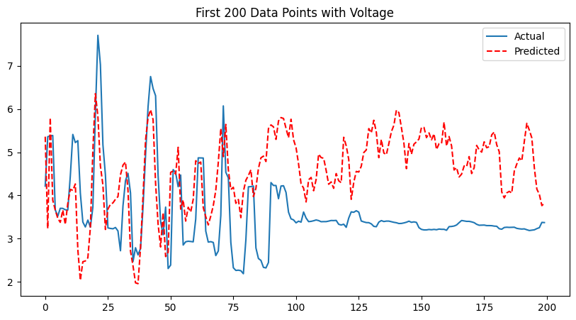

```python
#Plot first 200 data points/predictions for the expanded dataset
plt.figure(figsize=(10, 5))
plt.plot(ys['Global_active_power'][:200], label='Actual')
plt.plot(yp_pred[:200], 'r--', label='Predicted')
plt.legend()
plt.title("First 200 Data Points with Voltage")
plt.show()
```

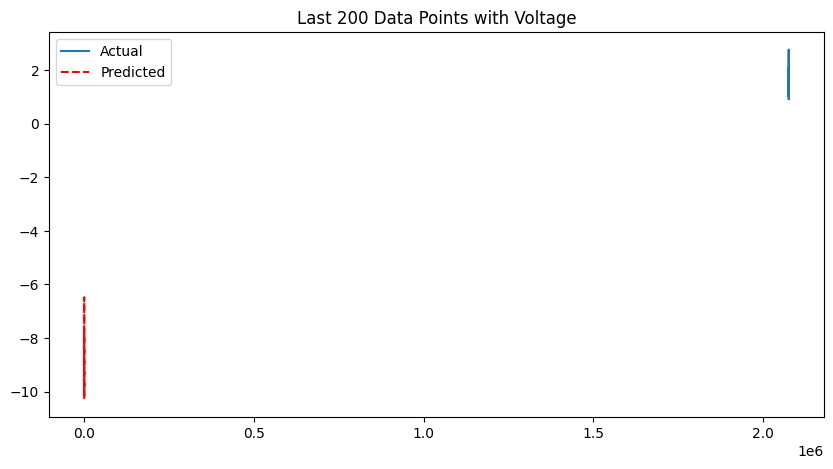

```python
#Plot last 200 data points/predictions for the expanded data
plt.figure(figsize=(10, 5))
plt.plot(ys['Global_active_power'][-200:], label='Actual')
plt.plot(yp_pred[-200:], 'r--', label='Predicted')
plt.legend()
plt.title("Last 200 Data Points with Voltage")
plt.show()
```

```python
#Calculate MSE of predictions for the expanded data
from sklearn.metrics import mean_squared_error as mse

# Ensure ph_index is an integer
ph_index = int(ph_index)
print("MSE is", mse(ys['Global_active_power'][ph_index:5000+ph_index-1],yp_pred))
```

```
MSE is 29.48963498279842
```

**Q: How did the model performed when you added the voltage data? How does it compare to the models without it?**

Early Predictions (First 200 Data Points) -

1. The new model aligns better with actual data than the previous time-only model.
2. Less deviation in predicted values.

Thus,

There are lots of other ways that we could try to improve our model while still using linear regression.

**TODO: Choose one alternative model and re-run the prediction code. Some ideas include:**

- Use a moving average as the response variable
- Make your prediction based on the time of day instead of as a continuous time series
- Use a moving window to limit your predictions instead of using a mu factor

**Q: Describe your alternative model and why it might improve your model**

A: I have chosen Moving Average (MA) model as the alternative approach. In this approach, I will use a moving average of Global_active_power as the response variable, instead of predicting the value at each time point. This helps smooth out noise and give a more stable prediction.

```python
# Parameters for the moving average
window_size = 10  # Size of the moving window for average (can be adjusted)

# Create moving averages for Global_active_power
ys = pd.DataFrame(df.Global_active_power)
ys['Moving_Avg'] = ys['Global_active_power'].rolling(window=window_size).mean()

# Drop rows with NaN values created by the rolling function
ys.dropna(inplace=True)

# Set prediction horizon (ph) to 5 minutes
ph = 5 * 60  # 5 minutes in seconds

# Data resolution (set to 1 minute based on your timestamps)
data_resolution = df.unix.diff().median()
ph_index = int(ph / data_resolution)

# Limit number of samples for speed
n_s = 5000

# Arrays to hold predicted values
tp_pred = np.zeros(n_s - window_size)  # Predictions for the moving window
yp_pred = np.zeros(n_s - window_size)  # Predicted values of Global_active_power
```

```python
#re-run the prediction code here
for i in range(window_size, n_s):  # Start at the first full window
    # Get the data in the moving window (last window_size points)
    ys_tmp = ys['Moving_Avg'].iloc[i - window_size:i].values

    # Make a simple prediction using the average of the window
    yp = np.mean(ys_tmp)  # Predicted value is the average of the last window_size points

    tp_pred[i - window_size] = df.unix.iloc[i]  # Predict the timestamp (time is continuous)
    yp_pred[i - window_size] = yp  # Store the predicted value (Moving Average)
```

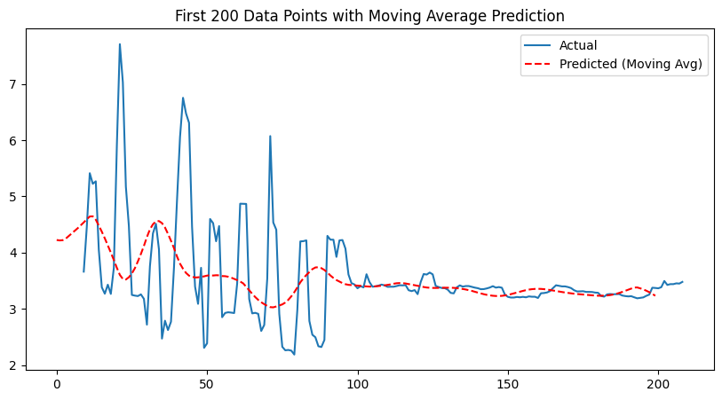

```python
#Plot first 200 data points/predictions for alternative model
plt.figure(figsize=(10, 5))
plt.plot(ys['Global_active_power'][:200], label='Actual')
plt.plot(yp_pred[:200], 'r--', label='Predicted (Moving Avg)')
plt.legend()
plt.title("First 200 Data Points with Moving Average Prediction")
plt.show()
```

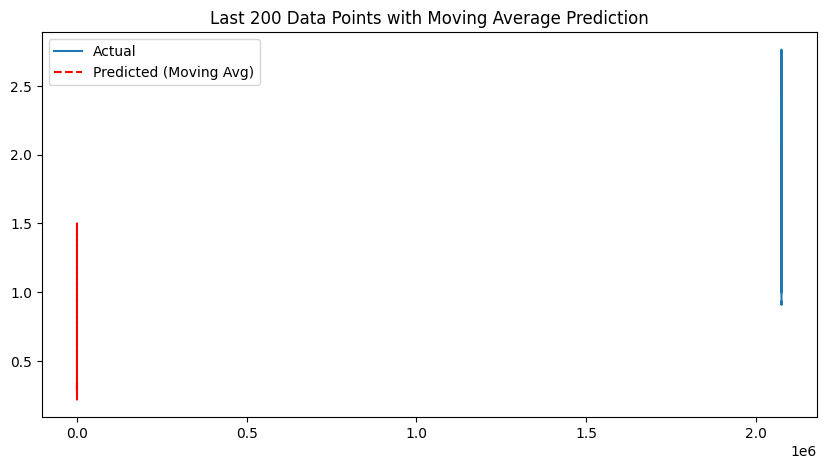

```python
#Plot last 200 data points/predictions for alternative model
plt.figure(figsize=(10, 5))
plt.plot(ys['Global_active_power'][-200:], label='Actual')
plt.plot(yp_pred[-200:], 'r--', label='Predicted (Moving Avg)')
plt.legend()
plt.title("Last 200 Data Points with Moving Average Prediction")
plt.show()
```

```python
#Calculate MSE of predictions for alternative model
from sklearn.metrics import mean_squared_error
mse_value = mean_squared_error(ys['Global_active_power'].iloc[window_size:n_s].values, yp_pred)
print("MSE with Moving Average Model:", mse_value)
```

```
MSE with Moving Average Model: 0.5673240801947895
```

**Q: Did your alternative model improve on our previous results? What else could you do to improve the model while still using linear regression?**

**Best Next Step:-** Incorporate Weighted Moving Averages with linear regression, or experiment with adding polynomial terms to better capture non-linear relationships. Experiment with advanced models like ARIMA or LSTM if the time series patterns are more complex than linear regression can handle.

It's worth noting that the results we're getting int his assignment are based on a pretty short predictive horizon of 5 minutes. If we were to increase our predictive horizon, our results would likely be worse and there would be more room for optimizing and improving the predictions of our model.